# GBIF

Julián A. Velasco

29 de julio de 2018

Vamos a buscar datos de especies de la base de datos disponible en línea y pública del Global Biodiversity Information Facility

Podemos usar unas funciones específicas que nos permitirán descargar los datos de las especies de interés.

Primero, cargaremos los paquetes necesarios: `dismo`, `raster`, `sp`

```r
# Es necesario que instalen los paquetes antes: install.packages("dismo")
library(dismo)
library(raster)
library(sp)

sp.gbif <- gbif(genus="Phrynosoma", species="modestum", geo=TRUE, removeZeros=TRUE, download=TRUE)
```

```
## 3032 records found
```

```
## 0-300-600-900-1200-1500-1800-2100-2400-2700-3000-3032 records downloaded
```

```r
names(sp.gbif) # vamos a ver todos los nombres de las columnas
```

```
##   [1] "acceptedNameUsage"
##   [2] "accessRights"
##   [3] "adm1"
##   [4] "adm2"
##   [5] "associatedReferences"
##   [6] "associatedSequences"
##   [7] "basisOfRecord"
##   [8] "bibliographicCitation"
##   [9] "catalogNumber"
##  [10] "class"
##  [11] "classKey"
##  [12] "cloc"
##  [13] "collectionCode"
##  [14] "collectionID"
##  [15] "continent"
```

[output cut: 126 more lines]

```r
sp.coords <- na.omit(sp.gbif[,c(124, 90, 83)]) # indexamos los datos de coordenadas (lon, lat)
head(sp.coords)
```

```
##   specificEpithet       lon      lat
## 1        modestum -106.6985 32.29295
## 2        modestum -102.6655 30.25169
## 3        modestum -106.6103 32.70861
## 4        modestum -107.6247 33.30399
## 5        modestum -100.7055 22.49427
## 6        modestum -106.3079 31.63903
```

Graficamos las coordenadas para explorar posibles sesgos espaciales

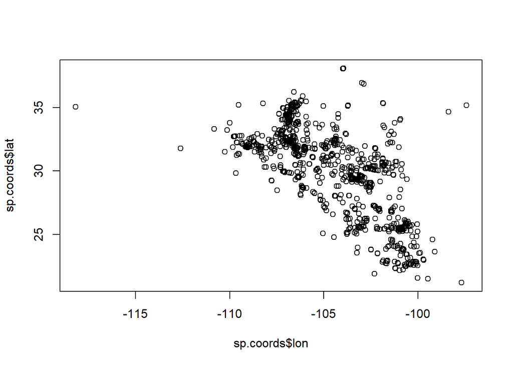

```r
plot(sp.coords$lon, sp.coords$lat)
```

Aquí vemos que hay muchos puntos muy agrupados. Este tipo de datos puede influir negativamente en la calibración del modelo de nicho y la predicción geográfica.

Vamos a tratar de reducir ese efecto adelgazando la muestra de puntos. Lo primero que hacemos es tratar de eliminar puntos a una distancia menor de 25 km. Como tenemos un tamaño de muestra grande (> 3000 registros) podemos hacer esto sin mucho problema. Usaremos el paquete `spThin` para esto.

```r
# 25 km minimum distance
library(spThin)
sp.thin <-thin(sp.coords, lat.col="lat", long.col="lon", spec.col="specificEpithet",
                 thin.par=25, reps=1, locs.thinned.list.return=TRUE, write.files=TRUE,
                 max.files=1, out.dir=".", out.base = "modestum.train.25km", write.log.file=TRUE, log.file="modestum.log.txt",
                 verbose=TRUE)
```

```
##  Beginning Spatial Thinning.
##  Script Started at: Sun Jul 29 13:43:02 2018
## lat.long.thin.count
## 307
##   1
## [1] "Maximum number of records after thinning: 307"
## [1] "Number of data.frames with max records: 1"
## [1] "Writing new *.csv files"
```

```
## [1] "Writing file: ./modestum.train.25km_thin1_new.csv"
```

Ahora vamos primero a identificar que tipo de objeto se acaba de generar:

```r
class(sp.thin)
```

```
## [1] "list"
```

```r
str(sp.thin)
```

```
## List of 1
##  $ :'data.frame':    307 obs. of  2 variables:
##   ..$ Longitude: num [1:307] -103 -108 -102 -106 -102 ...
##   ..$ Latitude : num [1:307] 30.3 33.3 30.1 31.5 30.7 ...
```

```r
head(sp.thin[[1]])
```

```
##    Longitude Latitude
## 2  -102.6655 30.25169
## 4  -107.6247 33.30399
## 10 -102.3864 30.10102
## 11 -106.0404 31.45543
## 12 -101.8940 30.65892
## 14 -101.3129 29.68367
```

Tenemos que tener en cuenta como vienen organizados los datos para luego manipularlos como queramos. Vamos a graficar los puntos adelgazados a una distancia no menor de 25 km.

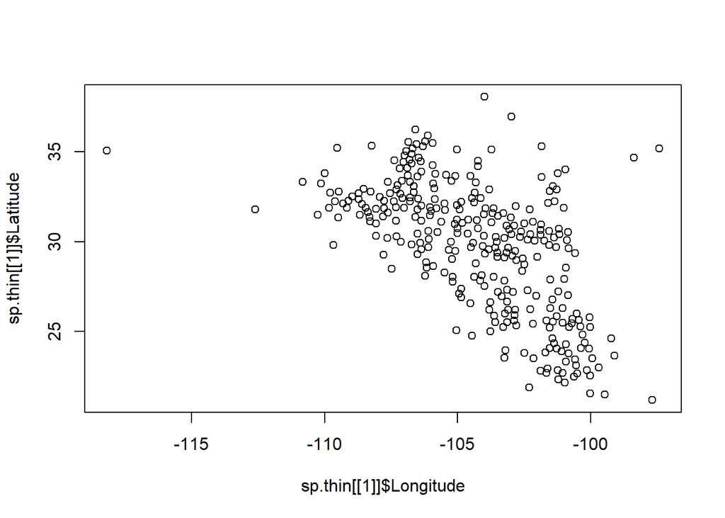

```r
plot(sp.thin[[1]]$Longitude, sp.thin[[1]]$Latitude)
```

Si comparamos con el objeto que contenia todos los puntos podemos ver que hemos reducido el sobre-muestreo en algunas regiones y esto nos facilitará la calibración y posterior predicción de nuestro modelo de nicho. Vamos a ver donde caen nuestros puntos dentro de un mapa.

Vamos a convertir nuestros puntos en un objeto espacial.

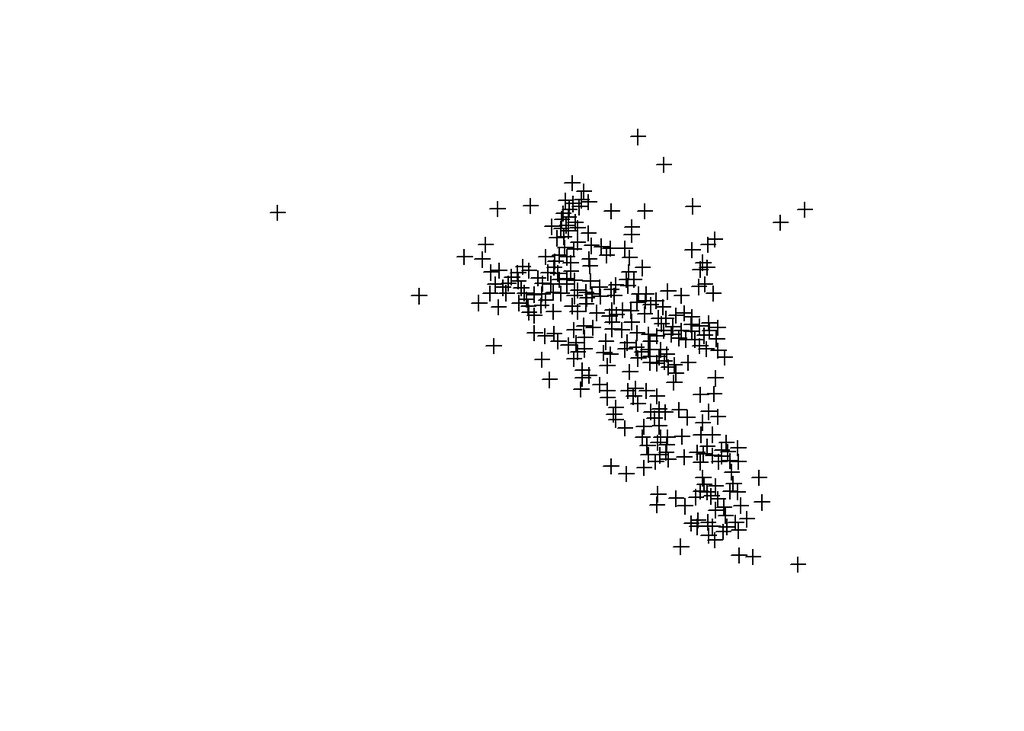

```r
coords <- sp.thin[[1]]
coordinates(coords)<- ~Longitude+Latitude

plot(coords)
```

```r
coords
```

```
## class       : SpatialPoints
## features    : 307
## extent      : -118.1731, -97.43912, 21.20054, 38.03594  (xmin, xmax, ymin, ymax)
## coord. ref. : NA
```

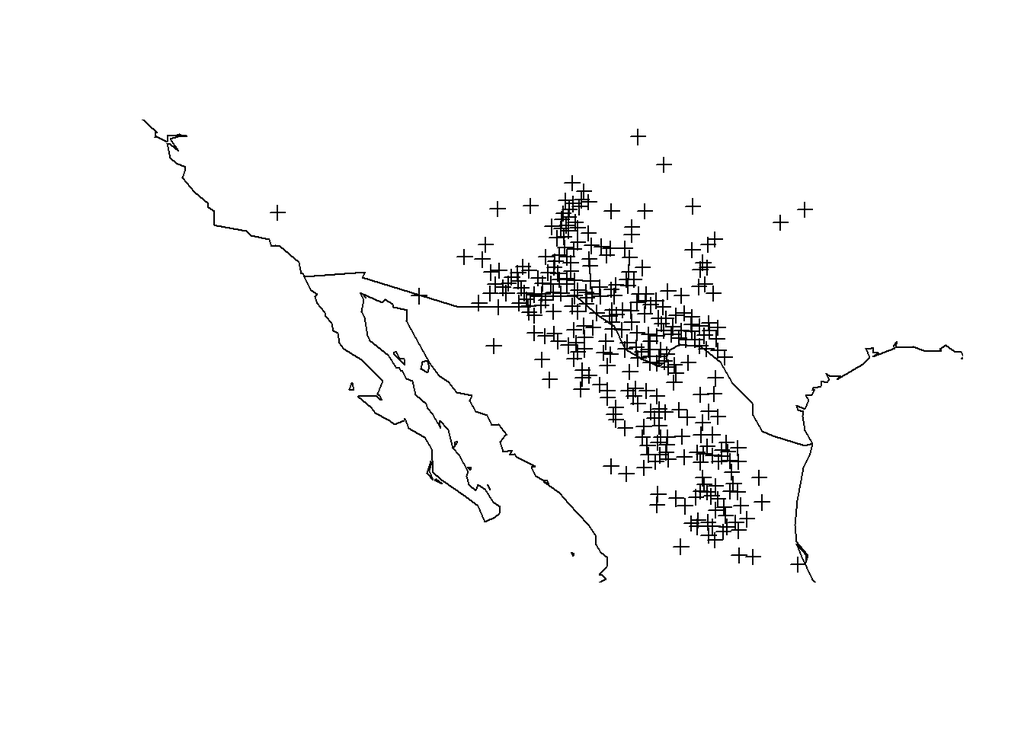

```r
plot(coords)
map(add = TRUE,  xlim=c(-118.1731,-97.43912), ylim=c(21.20054,38.03594))
```

Si solo nos interesan los puntos que se distribuyen en México, podríamos excluir los puntos que caen por fuera del país. Vamos a hacerlo. Primero necesitamos cargar el mapa de México.

```r
library(rgdal)
mx <- readOGR(dsn="C:/Users/juvel/Dropbox/Cursos_Charlas/Zaragosa_2018/Curso_FES_Zaragosa18/Poligono_Mexico", layer="gadm36_MEX_1")
```

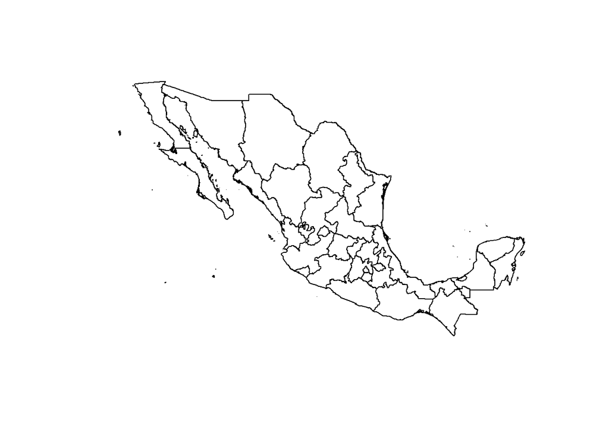

```r
plot(mx)
```

Ahora le ponemos los puntos encima al mapa…

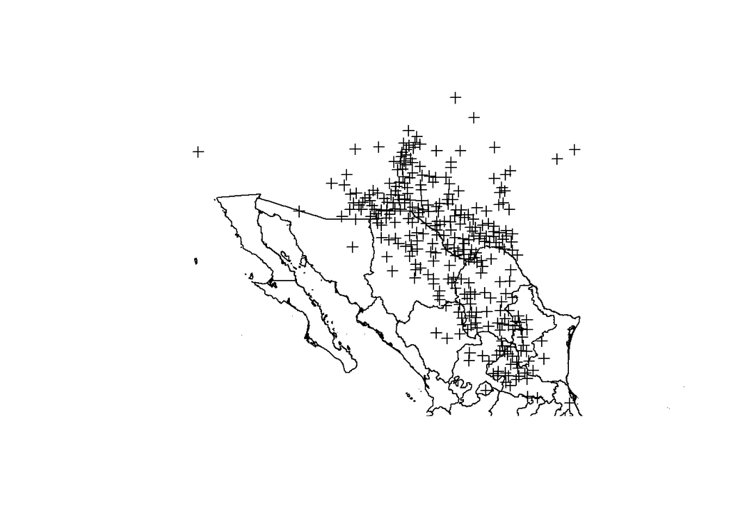

```r
plot(coords)
plot(mx, add=TRUE)
```

Con un `clip` vamos a quitar los puntos que caen por fuera. Pero primero definimos el sistema de coordenadas para nuestros puntos

```r
mx
```

```
## class       : SpatialPolygonsDataFrame
## features    : 32
## extent      : -118.3689, -86.71014, 14.53292, 32.71804  (xmin, xmax, ymin, ymax)
## coord. ref. : +proj=longlat +datum=WGS84 +no_defs +ellps=WGS84 +towgs84=0,0,0
## variables   : 10
## names       : GID_0, NAME_0,   GID_1,         NAME_1, VARNAME_1, NL_NAME_1,           TYPE_1,        ENGTYPE_1, CC_1, HASC_1
## min values  :   MEX, Mexico, MEX.1_1, Aguascalientes,        NA,        NA, Distrito Federal, Federal District,   NA,  MX.AG
## max values  :   MEX, Mexico, MEX.9_1,      Zacatecas,        NA,        NA,           Estado,            State,   NA,  MX.ZA
```

```r
crdref <- CRS("+proj=longlat +datum=WGS84 +no_defs +ellps=WGS84 +towgs84=0,0,0")
projection(coords)<-crdref
coords
```

```
## class       : SpatialPoints
## features    : 307
## extent      : -118.1731, -97.43912, 21.20054, 38.03594  (xmin, xmax, ymin, ymax)
## coord. ref. : +proj=longlat +datum=WGS84 +no_defs +ellps=WGS84 +towgs84=0,0,0
```

```r
coords.clip <- coords[mx, ]
```

```r
coords
```

```
## class       : SpatialPoints
## features    : 307
## extent      : -118.1731, -97.43912, 21.20054, 38.03594  (xmin, xmax, ymin, ymax)
## coord. ref. : +proj=longlat +datum=WGS84 +no_defs +ellps=WGS84 +towgs84=0,0,0
```

```r
coords.clip
```

```
## class       : SpatialPoints
## features    : 136
## extent      : -112.6083, -97.70008, 21.20054, 31.775  (xmin, xmax, ymin, ymax)
## coord. ref. : +proj=longlat +datum=WGS84 +no_defs +ellps=WGS84 +towgs84=0,0,0
```

Graficamos

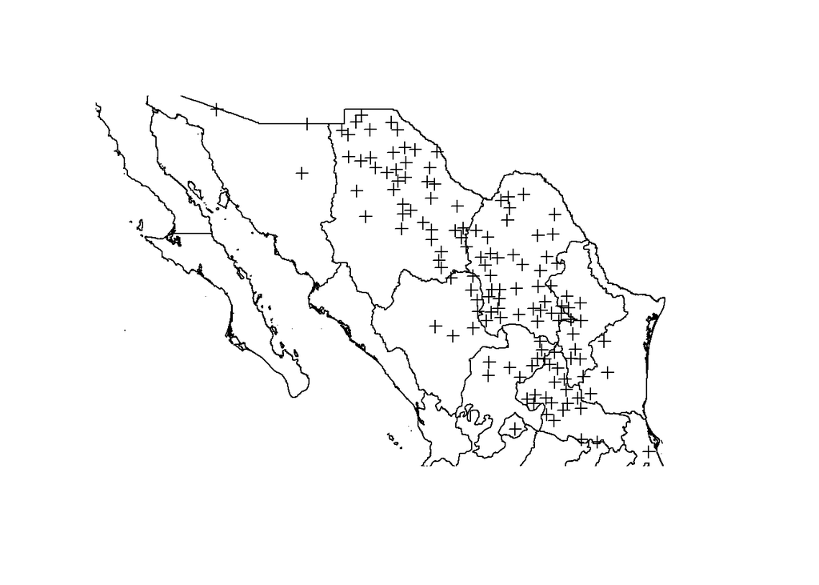

```r
plot(coords.clip)
plot(mx, add=TRUE)
```

Ahora tenemos nuestros puntos únicamente para México y los vamos a convertir en un objeto tipo `data.frame` con el fin de guardarlos en formato `CSV`y explorarlos con excel.

```r
coords.clipDF <- as.data.frame(coords.clip)
coords.clipDF
```

```
##       Longitude Latitude
## 19   -101.05979 22.71030
## 20   -101.52213 26.31369
## 26   -105.91661 28.65161
## 65   -104.86634 26.89161
## 66   -100.97070 22.16421
## 71   -101.00324 27.92715
## 72    -99.12439 23.64901
## 74   -100.80920 25.25199
## 76   -100.23816 24.36905
## 79   -101.10850 23.89352
## 107  -101.89556 22.82944
## 116   -99.94752 23.52748
## 131  -105.00584 30.46371
## 144  -101.71500 23.85833
```

[output cut: 122 more lines]

```r
write.csv(coords.clipDF, file="Coordenadas_GBIF_depuradas.csv")
```

Esto es todo por ahora!

Escrito por Julián A. Velasco, 29 de Julio de 2018.